# Analyse du prix des diamants

Antoine Sireyjol

20 janvier 2020

## Données et énoncé

Pour cet exercice, on utilise les données `diamonds` du package `ggplot2`. pour commencer, appliquez la fonction suivante aux données. Elle permet seulement de définir les facteurs ordonnés en facteurs simples puisque nous n’avons pas vu les facteurs ordonnés :

```r
library(dplyr)
```

```r
library(ggplot2)
diamonds <- ggplot2::diamonds %>% mutate_if(is.factor, ~ factor(., ordered = FALSE))
```

1. À l’aide de statistiques descriptives et de représentations graphiques (environ 4), présentez les effets des variables à disposition sur le prix des diamants.

**Une correction**

On imagine que le nombre de carats est un élément important. On commence par représenter son effet sur le prix, en déclinant en fonction des autres variables dont on dispose :

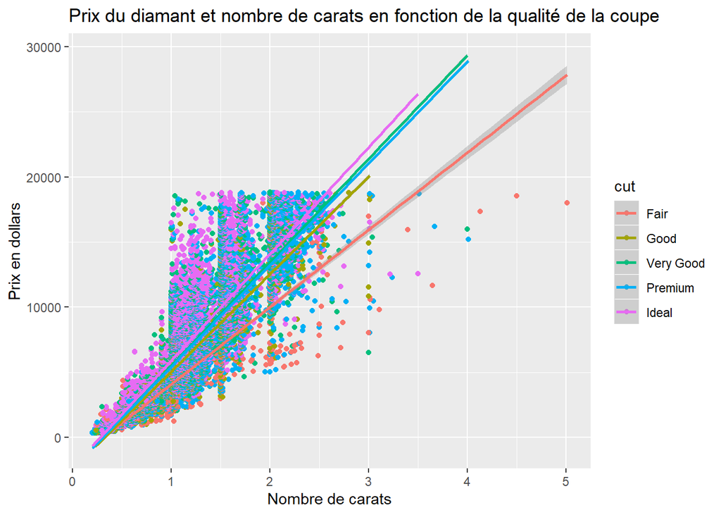

```r
diamonds %>% ggplot(aes(x = carat, y = price, color = cut)) +
  geom_point() +
  geom_smooth(method = "lm") +
   labs(title = "Prix du diamant et nombre de carats en fonction de la qualité de la coupe",
        x = "Nombre de carats",
        y = "Prix en dollars")
```

Le nombre de carats influe bien sur le prix, mais la qualité de la découpe va aussi avoir un rôle important : moins elle est bonne, plus le nombre de carats doit être élevé pour que le prix soit haut.

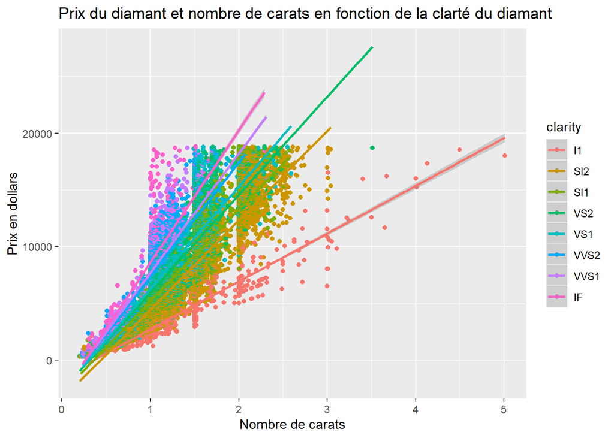

```r
diamonds %>% ggplot(aes(x = carat, y = price, color = clarity)) +
  geom_point() +
  geom_smooth(method = "lm") +
   labs(title = "Prix du diamant et nombre de carats en fonction de la clarté du diamant",
        x = "Nombre de carats",
        y = "Prix en dollars")
```

La clarté joue également un rôle : plus celle-ci est bonne, plus le prix augmente rapidement en fonction du nombre de carats.

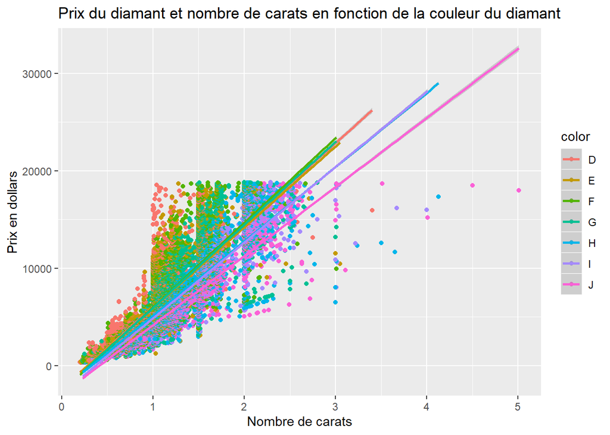

```r
diamonds %>% ggplot(aes(x = carat, y = price, color = color)) +
  geom_point() +
  geom_smooth(method = "lm") +
   labs(title = "Prix du diamant et nombre de carats en fonction de la couleur du diamant",
        x = "Nombre de carats",
        y = "Prix en dollars")
```

Enfin, la couleur du diamant joue également, même si on ne constate pas des différences entre les notes I et H et entre les notes allant de D à G.

Avant de partir sur la régression, on peut faire une matrice de corrélation pour voir les relations des variables entre elles :

```r
cor(diamonds %>% mutate_if(~ !is.numeric(.), as.numeric) %>% filter_all(any_vars(!is.na(.))))
```

```
##               carat         cut       color     clarity       depth
## carat    1.00000000 -0.13496702  0.29143675 -0.35284057  0.02822431
## cut     -0.13496702  1.00000000 -0.02051852  0.18917474 -0.21805501
## color    0.29143675 -0.02051852  1.00000000  0.02563128  0.04727923
## clarity -0.35284057  0.18917474  0.02563128  1.00000000 -0.06738444
## depth    0.02822431 -0.21805501  0.04727923 -0.06738444  1.00000000
## table    0.18161755 -0.43340461  0.02646520 -0.16032684 -0.29577852
## price    0.92159130 -0.05349066  0.17251093 -0.14680007 -0.01064740
## x        0.97509423 -0.12556524  0.27028669 -0.37199853 -0.02528925
## y        0.95172220 -0.12146187  0.26358440 -0.35841962 -0.02934067
## z        0.95338738 -0.14932254  0.26822688 -0.36695200  0.09492388
##              table       price           x           y           z
## carat    0.1816175  0.92159130  0.97509423  0.95172220  0.95338738
## cut     -0.4334046 -0.05349066 -0.12556524 -0.12146187 -0.14932254
## color    0.0264652  0.17251093  0.27028669  0.26358440  0.26822688
## clarity -0.1603268 -0.14680007 -0.37199853 -0.35841962 -0.36695200
## depth   -0.2957785 -0.01064740 -0.02528925 -0.02934067  0.09492388
## table    1.0000000  0.12713390  0.19534428  0.18376015  0.15092869
## price    0.1271339  1.00000000  0.88443516  0.86542090  0.86124944
## x        0.1953443  0.88443516  1.00000000  0.97470148  0.97077180
## y        0.1837601  0.86542090  0.97470148  1.00000000  0.95200572
## z        0.1509287  0.86124944  0.97077180  0.95200572  1.00000000
```

On remarque notamment que les variables `carat`, `x`, `y` et `z` sont très corrélées : on n’a peut-être pas besoin de toutes les inclure.

2. Construisez un modèle permettant de prédire le prix d’un diamant à partir de ses caractéristiques. Présentez sa précision à l’aide d’une méthode d’évaluation croisée.

**Une correction possible** Regardons ce que donne le modèle avec toutes les variables :

```r
model_diamonds <- lm(price ~ ., data = diamonds)
summary(model_diamonds)
```

```
##
## Call:
## lm(formula = price ~ ., data = diamonds)
##
## Residuals:
##      Min       1Q   Median       3Q      Max
## -21376.0   -592.4   -183.5    376.4  10694.2
##
## Coefficients:
##               Estimate Std. Error t value Pr(>|t|)
## (Intercept)   2184.477    408.197   5.352 8.76e-08 ***
## carat        11256.978     48.628 231.494  < 2e-16 ***
## cutGood        579.751     33.592  17.259  < 2e-16 ***
## cutVery Good   726.783     32.241  22.542  < 2e-16 ***
## cutPremium     762.144     32.228  23.649  < 2e-16 ***
## cutIdeal       832.912     33.407  24.932  < 2e-16 ***
## colorE        -209.118     17.893 -11.687  < 2e-16 ***
## colorF        -272.854     18.093 -15.081  < 2e-16 ***
## colorG        -482.039     17.716 -27.209  < 2e-16 ***
## colorH        -980.267     18.836 -52.043  < 2e-16 ***
## colorI       -1466.244     21.162 -69.286  < 2e-16 ***
## colorJ       -2369.398     26.131 -90.674  < 2e-16 ***
## claritySI2    2702.586     43.818  61.677  < 2e-16 ***
## claritySI1    3665.472     43.634  84.005  < 2e-16 ***
## clarityVS2    4267.224     43.853  97.306  < 2e-16 ***
## clarityVS1    4578.398     44.546 102.779  < 2e-16 ***
## clarityVVS2   4950.814     45.855 107.967  < 2e-16 ***
## clarityVVS1   5007.759     47.160 106.187  < 2e-16 ***
## clarityIF     5345.102     51.024 104.757  < 2e-16 ***
## depth          -63.806      4.535 -14.071  < 2e-16 ***
## table          -26.474      2.912  -9.092  < 2e-16 ***
## x            -1008.261     32.898 -30.648  < 2e-16 ***
## y                9.609     19.333   0.497    0.619
## z              -50.119     33.486  -1.497    0.134
## ---
## Signif. codes:  0 '***' 0.001 '**' 0.01 '*' 0.05 '.' 0.1 ' ' 1
##
## Residual standard error: 1130 on 53916 degrees of freedom
## Multiple R-squared:  0.9198, Adjusted R-squared:  0.9198
## F-statistic: 2.688e+04 on 23 and 53916 DF,  p-value: < 2.2e-16
```

`y` et `z` n’ont pas de coefficients significatifs, sans doute du fait qu’ils sont déjà très corrélés à `x` et `carat`. On peut utiliser une méthode automatique de sélection de variables (avec le package `MASS` par exemple) :

```r
# Pour sélectionner le meilleur modèle on utilise stepAIC du package MASS
best_mod <- MASS::stepAIC(model_diamonds, direction = "both", trace = FALSE)

summary(best_mod)
```

```
##
## Call:
## lm(formula = price ~ carat + cut + color + clarity + depth +
##     table + x + z, data = diamonds)
##
## Residuals:
##      Min       1Q   Median       3Q      Max
## -21378.8   -592.5   -183.5    376.3  10694.1
##
## Coefficients:
##               Estimate Std. Error t value Pr(>|t|)
## (Intercept)   2198.886    407.163   5.401 6.67e-08 ***
## carat        11257.752     48.602 231.630  < 2e-16 ***
## cutGood        580.325     33.572  17.286  < 2e-16 ***
## cutVery Good   727.431     32.214  22.581  < 2e-16 ***
## cutPremium     762.287     32.226  23.654  < 2e-16 ***
## cutIdeal       833.352     33.396  24.954  < 2e-16 ***
## colorE        -209.100     17.893 -11.686  < 2e-16 ***
## colorF        -272.837     18.093 -15.080  < 2e-16 ***
## colorG        -482.035     17.716 -27.209  < 2e-16 ***
## colorH        -980.247     18.836 -52.042  < 2e-16 ***
## colorI       -1466.257     21.162 -69.287  < 2e-16 ***
## colorJ       -2369.412     26.131 -90.675  < 2e-16 ***
## claritySI2    2702.855     43.815  61.688  < 2e-16 ***
## claritySI1    3665.735     43.631  84.018  < 2e-16 ***
## clarityVS2    4267.476     43.850  97.319  < 2e-16 ***
## clarityVS1    4578.702     44.541 102.796  < 2e-16 ***
## clarityVVS2   4951.100     45.851 107.983  < 2e-16 ***
## clarityVVS1   5008.029     47.156 106.201  < 2e-16 ***
## clarityIF     5345.420     51.020 104.772  < 2e-16 ***
## depth          -64.003      4.517 -14.168  < 2e-16 ***
## table          -26.501      2.911  -9.103  < 2e-16 ***
## x            -1000.354     28.795 -34.740  < 2e-16 ***
## z              -47.925     33.194  -1.444    0.149
## ---
## Signif. codes:  0 '***' 0.001 '**' 0.01 '*' 0.05 '.' 0.1 ' ' 1
##
## Residual standard error: 1130 on 53917 degrees of freedom
## Multiple R-squared:  0.9198, Adjusted R-squared:  0.9198
## F-statistic: 2.81e+04 on 22 and 53917 DF,  p-value: < 2.2e-16
```

Il enlève en effet la variable `y`.

On utilise `bestmod` pour construire notre prédiction et on l’évalue en k-fold cross validation à l’aide du package `caret` :

```r
train.control <- caret::trainControl(method = "cv", number = 10)

# On entraîne le modèle
model_cv <- caret::train(price ~ .,
                         data = best_mod$model,
                         na.action  = na.pass,
                         method = "lm",
                         trControl = train.control)
# On affiche les résultats
print(model_cv)
```

```
## Linear Regression
##
## 53940 samples
##     8 predictor
##
## No pre-processing
## Resampling: Cross-Validated (10 fold)
## Summary of sample sizes: 48545, 48547, 48545, 48546, 48546, 48547, ...
## Resampling results:
##
##   RMSE      Rsquared   MAE
##   1130.807  0.9197099  740.4263
##
## Tuning parameter 'intercept' was held constant at a value of TRUE
```

On peut comparer les résultats aux valeurs prises par la variable `price` :

```r
summary(diamonds$price)
```

```
##    Min. 1st Qu.  Median    Mean 3rd Qu.    Max.
##     326     950    2401    3933    5324   18823
```

On peut essayer de voir si l’erreur du modèle est stable en fonction du prix :

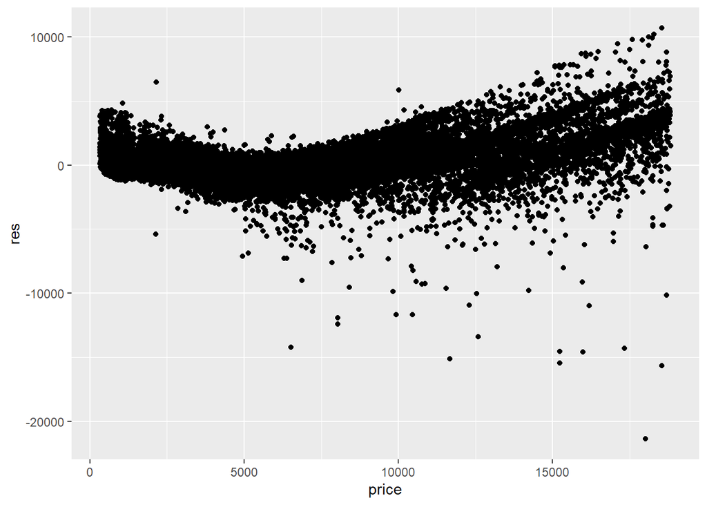

```r
diamonds$res <- best_mod$residuals
ggplot(data = diamonds, aes(x = price, y = res)) +
  geom_point()
```

La spécification linéaire n’était peut-être pas idéale? Les plots de diagnostics donnent :

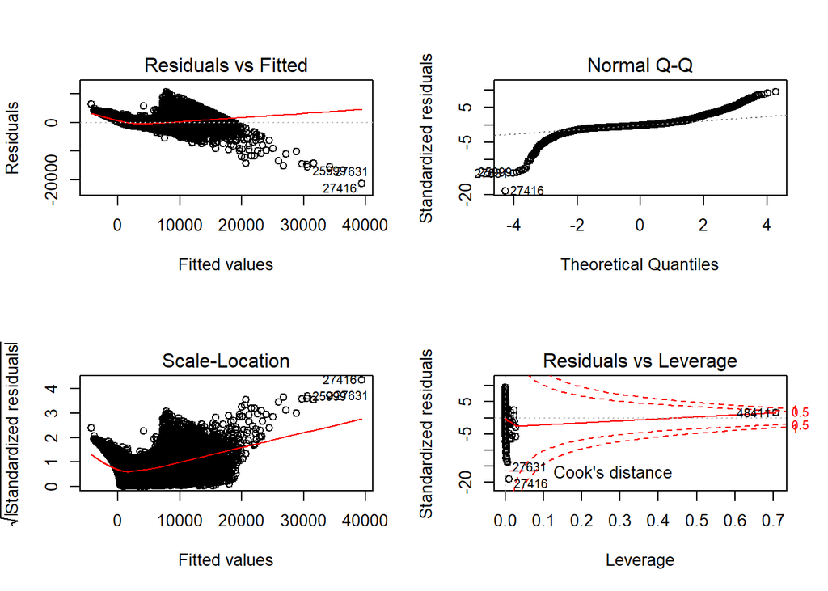

```r
par(mfrow = c(2, 2))
plot(best_mod)
```

```r
par(mfrow = c(1, 1))
```

Il semblerait que notre modèle ait du mal à évaluer correctement les valeurs extrêmes (faibles ou non). Une méthode “à la main” pourrait être d’ajouter des indicatrices pour essayer de corriger ce défaut :

```r
diamonds$ind_low <- (diamonds$price < 3000)
diamonds$ind_up <- (diamonds$price > 10000)
model_diamonds_bis <- lm(price ~ ., data = diamonds %>% select(-res))
summary(model_diamonds_bis)
```

```
##
## Call:
## lm(formula = price ~ ., data = diamonds %>% select(-res))
##
## Residuals:
##      Min       1Q   Median       3Q      Max
## -11212.8   -408.4   -103.4    312.8   7669.2
##
## Coefficients:
##               Estimate Std. Error t value Pr(>|t|)
## (Intercept)  -2905.766    322.871  -9.000  < 2e-16 ***
## carat         5963.512     46.044 129.518  < 2e-16 ***
## cutGood        421.001     25.665  16.404  < 2e-16 ***
## cutVery Good   532.056     24.649  21.586  < 2e-16 ***
## cutPremium     531.759     24.624  21.595  < 2e-16 ***
## cutIdeal       592.482     25.530  23.207  < 2e-16 ***
## colorE        -145.793     13.646 -10.684  < 2e-16 ***
## colorF        -171.816     13.807 -12.444  < 2e-16 ***
## colorG        -290.389     13.552 -21.428  < 2e-16 ***
## colorH        -667.800     14.455 -46.199  < 2e-16 ***
## colorI        -980.688     16.395 -59.816  < 2e-16 ***
## colorJ       -1576.031     20.419 -77.184  < 2e-16 ***
## claritySI2    1723.933     33.871  50.896  < 2e-16 ***
## claritySI1    2386.895     34.005  70.193  < 2e-16 ***
## clarityVS2    2860.084     34.334  83.302  < 2e-16 ***
## clarityVS1    3073.164     34.988  87.835  < 2e-16 ***
## clarityVVS2   3313.331     36.138  91.685  < 2e-16 ***
## clarityVVS1   3317.661     37.202  89.179  < 2e-16 ***
## clarityIF     3544.945     40.193  88.198  < 2e-16 ***
## depth           -7.160      3.493  -2.050 0.040418 *
## table          -12.536      2.222  -5.642 1.69e-08 ***
## x              101.666     26.668   3.812 0.000138 ***
## y                5.733     14.735   0.389 0.697202
## z              -15.906     25.520  -0.623 0.533110
## ind_lowTRUE   -843.746     14.637 -57.647  < 2e-16 ***
## ind_upTRUE    4002.713     20.293 197.244  < 2e-16 ***
## ---
## Signif. codes:  0 '***' 0.001 '**' 0.01 '*' 0.05 '.' 0.1 ' ' 1
##
## Residual standard error: 861.2 on 53914 degrees of freedom
## Multiple R-squared:  0.9534, Adjusted R-squared:  0.9534
## F-statistic: 4.414e+04 on 25 and 53914 DF,  p-value: < 2.2e-16
```

```r
# Pour sélectionner le meilleur modèle on utilise stepAIC du package MASS
best_mod_bis <- MASS::stepAIC(model_diamonds_bis, direction = "both", trace = FALSE)

summary(best_mod_bis)
```

```
##
## Call:
## lm(formula = price ~ carat + cut + color + clarity + depth +
##     table + x + ind_low + ind_up, data = diamonds %>% select(-res))
##
## Residuals:
##      Min       1Q   Median       3Q      Max
## -11216.2   -408.3   -103.4    312.8   7669.2
##
## Coefficients:
##               Estimate Std. Error t value Pr(>|t|)
## (Intercept)  -2846.425    310.034  -9.181  < 2e-16 ***
## carat         5963.614     46.022 129.582  < 2e-16 ***
## cutGood        421.315     25.651  16.425  < 2e-16 ***
## cutVery Good   532.254     24.627  21.612  < 2e-16 ***
## cutPremium     531.985     24.622  21.606  < 2e-16 ***
## cutIdeal       592.712     25.521  23.224  < 2e-16 ***
## colorE        -145.823     13.646 -10.686  < 2e-16 ***
## colorF        -171.803     13.806 -12.444  < 2e-16 ***
## colorG        -290.355     13.551 -21.426  < 2e-16 ***
## colorH        -667.743     14.454 -46.197  < 2e-16 ***
## colorI        -980.663     16.395 -59.816  < 2e-16 ***
## colorJ       -1576.051     20.419 -77.186  < 2e-16 ***
## claritySI2    1723.837     33.867  50.901  < 2e-16 ***
## claritySI1    2386.774     34.000  70.200  < 2e-16 ***
## clarityVS2    2859.943     34.329  83.310  < 2e-16 ***
## clarityVS1    3072.976     34.980  87.849  < 2e-16 ***
## clarityVVS2   3313.185     36.132  91.696  < 2e-16 ***
## clarityVVS1   3317.493     37.197  89.188  < 2e-16 ***
## clarityIF     3544.768     40.186  88.208  < 2e-16 ***
## depth           -8.118      3.162  -2.567   0.0102 *
## table          -12.538      2.221  -5.645 1.66e-08 ***
## x               97.544     18.296   5.331 9.78e-08 ***
## ind_lowTRUE   -843.754     14.634 -57.659  < 2e-16 ***
## ind_upTRUE    4002.802     20.292 197.256  < 2e-16 ***
## ---
## Signif. codes:  0 '***' 0.001 '**' 0.01 '*' 0.05 '.' 0.1 ' ' 1
##
## Residual standard error: 861.2 on 53916 degrees of freedom
## Multiple R-squared:  0.9534, Adjusted R-squared:  0.9534
## F-statistic: 4.798e+04 on 23 and 53916 DF,  p-value: < 2.2e-16
```

```r
train.control.bis <- caret::trainControl(method = "cv", number = 10)

# On entraîne le modèle
model_cv_bis <- caret::train(price ~ .,
                         data = best_mod_bis$model,
                         na.action  = na.pass,
                         method = "lm",
                         trControl = train.control.bis)
# On affiche les résultats
print(model_cv_bis)
```

```
## Linear Regression
##
## 53940 samples
##     9 predictor
##
## No pre-processing
## Resampling: Cross-Validated (10 fold)
## Summary of sample sizes: 48546, 48546, 48546, 48546, 48546, 48546, ...
## Resampling results:
##
##   RMSE      Rsquared   MAE
##   861.5658  0.9533781  570.6561
##
## Tuning parameter 'intercept' was held constant at a value of TRUE
```

On améliore de manière significative la performance prédictive de notre modèle, mais la distribution des résidus n’est pas satisfaisante (voir ci-dessous).

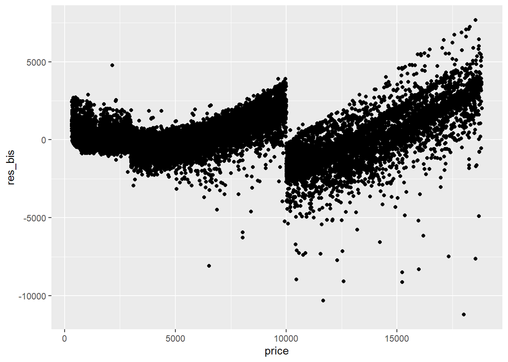

```r
diamonds$res_bis <- best_mod_bis$residuals
ggplot(data = diamonds, aes(x = price, y = res_bis)) +
  geom_point()
```

C’est la transformation de price en log(price) qui permet d’avoir un meilleur ajustement du modèle linéaire :

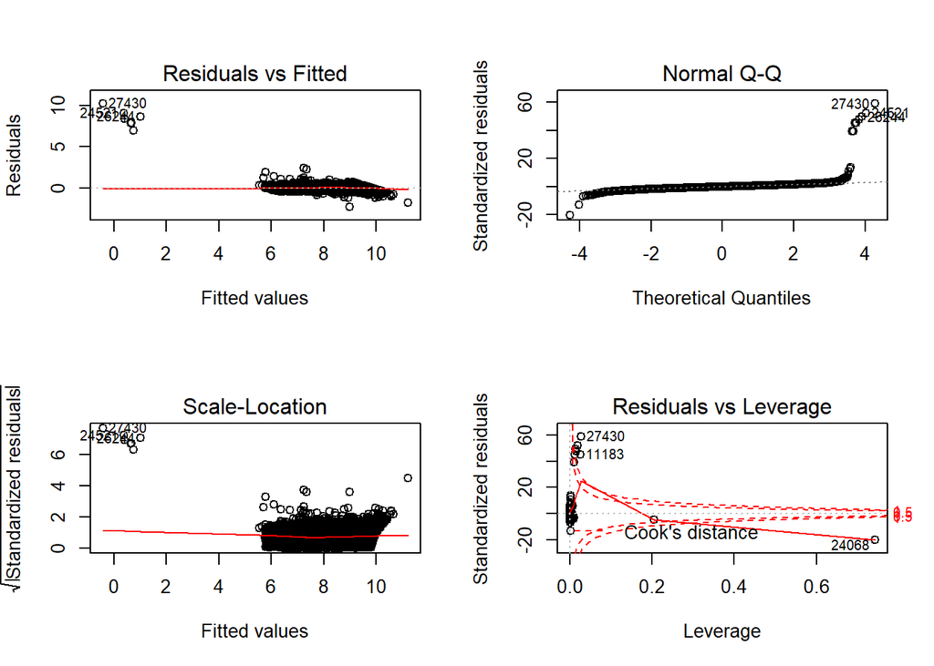

```r
log_mod <- lm(log(price) ~ carat + cut + color + clarity + depth + table + x + y, data = diamonds)

par(mfrow = c(2, 2))
plot(log_mod)
```

```r
par(mfrow = c(1, 1))
```